# Lecture 11 - Class Activity: Multiple Regression

Author

# Analysis of Net Primary Production in Forests: A Modern Tidyverse Approach

*Based on Michaletz et al. (2014) data*

## Introduction

This analysis examines the relationships between Net Primary Production (npp) and various climate and forest characteristics across global forest sites. We’ll explore multicollinearity, model selection, and variable transformations.

**Key Learning Objectives:**

- Understand multicollinearity in multiple regression
- Learn model diagnostics and assumption checking
- Practice variable selection techniques
- Apply data transformations appropriately

## Load Required Packages

```r
# Load required packages
library(tidyverse)    # For data manipulation and visualization
library(car)          # For regression diagnostics (VIF, etc.)
library(corrplot)     # For correlation plots
library(GGally)       # For pairs plots
library(broom)        # For tidy model outputs
library(performance)  # For model performance metrics
library(see)          # For better diagnostic plots
```

## Load and Explore the Data

```r
# Load the forest npp data
forest_data <- read_csv("data/michaletz_etal_2014.csv")
# Display top lines
head(forest_data)
```

```
# A tibble: 6 × 15
  Index    Lat  Long NPPTotal_gm2y Age_yr BiomassTotal_gm2 Lgs_mo MAT_C MAP_mm
  <dbl>  <dbl> <dbl>         <dbl>  <dbl>            <dbl>  <dbl> <dbl>  <dbl>
1  1243 -13.1  -52.4          2084   104.           18198.     11 25.3   1888
2  1241  -1.72 -51.4          2234   333.           54523.     12 26.9   2348.
3  1242  -1.72 -51.4          2714   213.           41358.     12 26.9   2348.
4  1235  -3.95 -73.4          2828   114.           31557.     12 26.7   2784.
5  1236  -3.95 -73.4          2882   113.           21417      12 26.7   2784.
6   672  51.7  113.            774    79            11188       3 -3.53   408.
# ℹ 6 more variables: LeafType <chr>, TEB_DD <dbl>, Source <chr>,
#   SourceIndex <chr>, SourcePrimary <chr>,
#   `Methodology for biomass and production` <chr>
```

## Data Preparation

Following the original analysis, we’ll focus on the key variables and create our working dataframe:

```r
# Create working dataset with key variables
# Following the original script's variable selection
forest_clean <- forest_data %>%
  select(
    npp = NPPTotal_gm2y,           # Net Primary Production (response variable)
    age =  Age_yr,                   # Stand age in years
    biomass =  BiomassTotal_gm2,     # Total biomass
    season =  Lgs_mo,        # Length of growing season in months
    temp =  MAT_C,            # Mean annual temperature
    precip  = MAP_mm,         # Mean annual precipitation
    teb =  TEB_DD,                   # Thermal environment
    leaf = LeafType                        # Leaf type (categorical)
  ) %>%
  # Remove any rows with missing values in key variables
  drop_na()

forest_clean <- forest_clean %>% mutate(leaf = as.factor(leaf))


# Display the cleaned dataset
glimpse(forest_clean)
```

```
Rows: 1,220
Columns: 8
$ npp     <dbl> 2084, 2234, 2714, 2828, 2882, 774, 1052, 3100, 2254, 785, 1673…
$ age     <dbl> 104.429, 333.268, 213.382, 114.231, 113.477, 79.000, 60.000, 6…
$ biomass <dbl> 18198.4, 54522.6, 41357.8, 31556.8, 21417.0, 11188.0, 24520.0,…
$ season  <dbl> 11, 12, 12, 12, 12, 3, 6, 12, 12, 6, 6, 5, 5, 5, 5, 5, 5, 5, 5…
$ temp    <dbl> 25.283333, 26.916667, 26.916667, 26.725000, 26.725000, -3.5333…
$ precip  <dbl> 1888.0, 2348.5, 2348.5, 2784.4, 2784.4, 407.8, 1128.7, 1079.3,…
$ teb     <dbl> 0.55, 0.60, 0.60, 1.25, 1.25, 1.80, 2.05, 2.05, 2.05, 2.05, 2.…
$ leaf    <fct> broadleaf, broadleaf, broadleaf, broadleaf, broadleaf, broadle…
```

## 1. Initial Exploration: Variable Relationships and Multicollinearity

### Correlation Matrix and Visualization

```r
# Create correlation matrix for numeric variables only
numeric_vars <- forest_clean %>%
  select_if(is.numeric)

# Calculate correlation matrix
cor_matrix <- cor(numeric_vars, use = "complete.obs")

# Display correlation matrix
print(round(cor_matrix, 3))
```

```
           npp    age biomass season   temp precip    teb
npp      1.000 -0.153   0.459  0.561  0.552  0.531 -0.317
age     -0.153  1.000   0.592 -0.272 -0.231  0.004 -0.012
biomass  0.459  0.592   1.000  0.132  0.155  0.354 -0.275
season   0.561 -0.272   0.132  1.000  0.923  0.568 -0.249
temp     0.552 -0.231   0.155  0.923  1.000  0.577 -0.250
precip   0.531  0.004   0.354  0.568  0.577  1.000 -0.291
teb     -0.317 -0.012  -0.275 -0.249 -0.250 -0.291  1.000
```

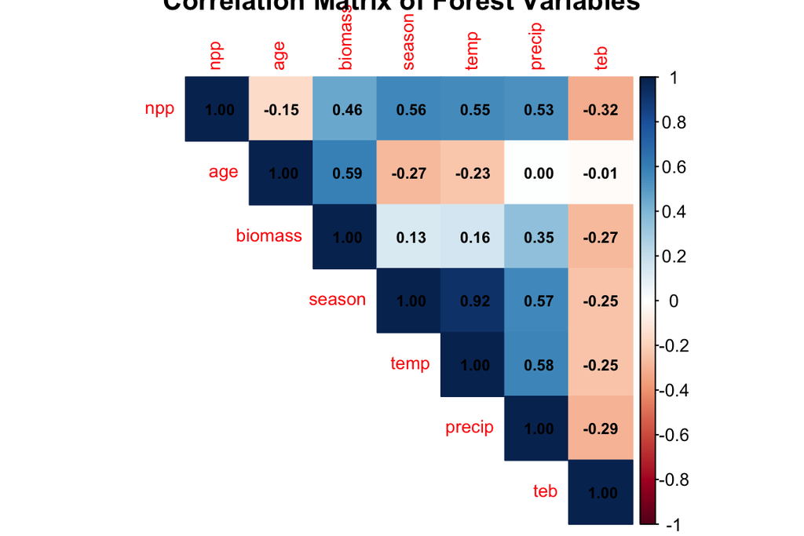

```r
# Create a visual correlation plot
corrplot(cor_matrix, method = "color", type = "upper",
         addCoef.col = "black", tl.cex = 0.8, number.cex = 0.7,
         title = "Correlation Matrix of Forest Variables")
```

### Pairs Plot for Visual Inspection

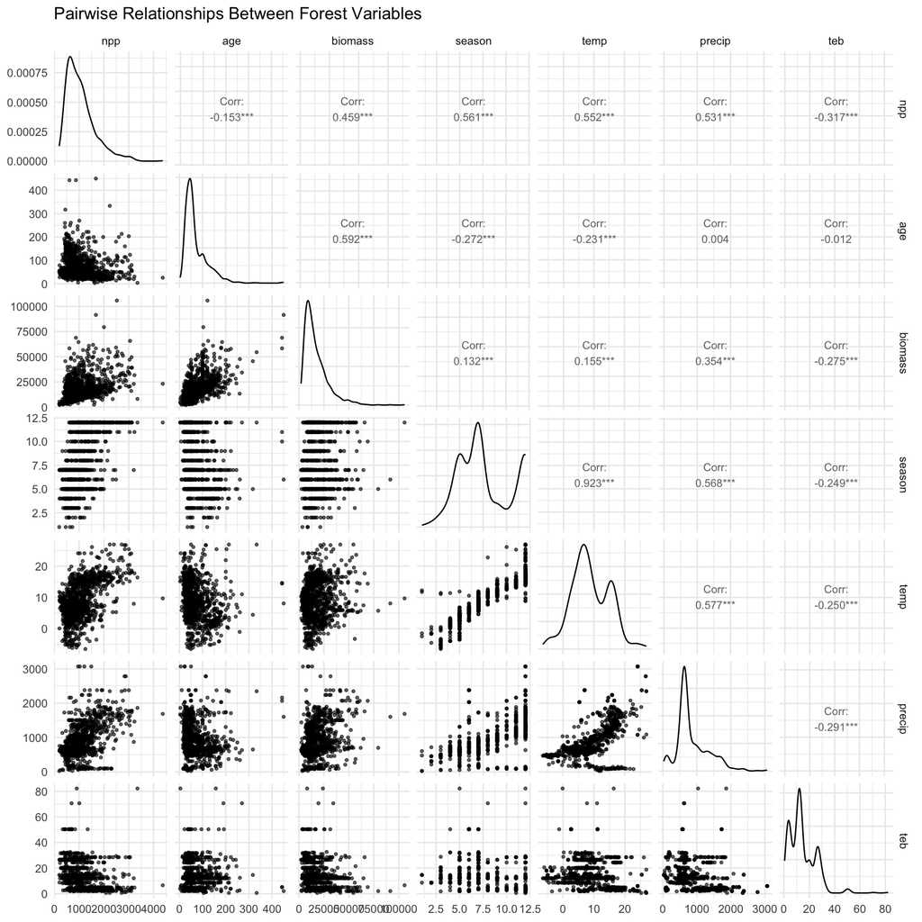

```r
# Create pairs plot to visualize relationships
# This replaces the original pairs() function with ggplot2
forest_clean %>%
  select(-leaf) %>%  # Exclude categorical variable for pairs plot
  ggpairs(
    title = "Pairwise Relationships Between Forest Variables",
    upper = list(continuous = wrap("cor", size = 3)),
    lower = list(continuous = wrap("points", alpha = 0.6, size = 0.8))
  ) +
  theme_minimal()
```

## 2. Initial Multiple Regression Model

Let’s start with a full model including all predictors:

```r
# Fit initial model with all predictors (Model 1)
model1 <- lm(npp ~ age + biomass + season + temp +
             precip + teb + leaf, data = forest_clean)

# Get model summary
summary(model1)
```

```
Call:
lm(formula = npp ~ age + biomass + season + temp + precip + teb +
    leaf, data = forest_clean)

Residuals:
     Min       1Q   Median       3Q      Max
-1331.10  -206.27   -34.09   166.94  2760.41

Coefficients:
              Estimate Std. Error t value Pr(>|t|)
(Intercept)  583.92959   53.81169  10.851  < 2e-16 ***
age           -4.78822    0.28518 -16.790  < 2e-16 ***
biomass        0.03154    0.00122  25.848  < 2e-16 ***
season        41.18220    9.49073   4.339 1.55e-05 ***
temp           4.61281    4.37372   1.055 0.291788
precip         0.09674    0.02852   3.392 0.000716 ***
teb           -2.12880    1.08408  -1.964 0.049794 *
leafneedle  -267.00569   22.43078 -11.904  < 2e-16 ***
---
Signif. codes:  0 '***' 0.001 '**' 0.01 '*' 0.05 '.' 0.1 ' ' 1

Residual standard error: 351.7 on 1212 degrees of freedom
Multiple R-squared:  0.6415,    Adjusted R-squared:  0.6394
F-statistic: 309.8 on 7 and 1212 DF,  p-value: < 2.2e-16
```

### Check for Multicollinearity

```r
# Calculate Variance Inflation Factors (VIF)
vif_values <- vif(model1)
print("Variance Inflation Factors:")
```

```
[1] "Variance Inflation Factors:"
```

```r
print(vif_values)
```

```
     age  biomass   season     temp   precip      teb     leaf
1.993348 2.061766 7.079004 6.972147 1.831127 1.167007 1.236588
```

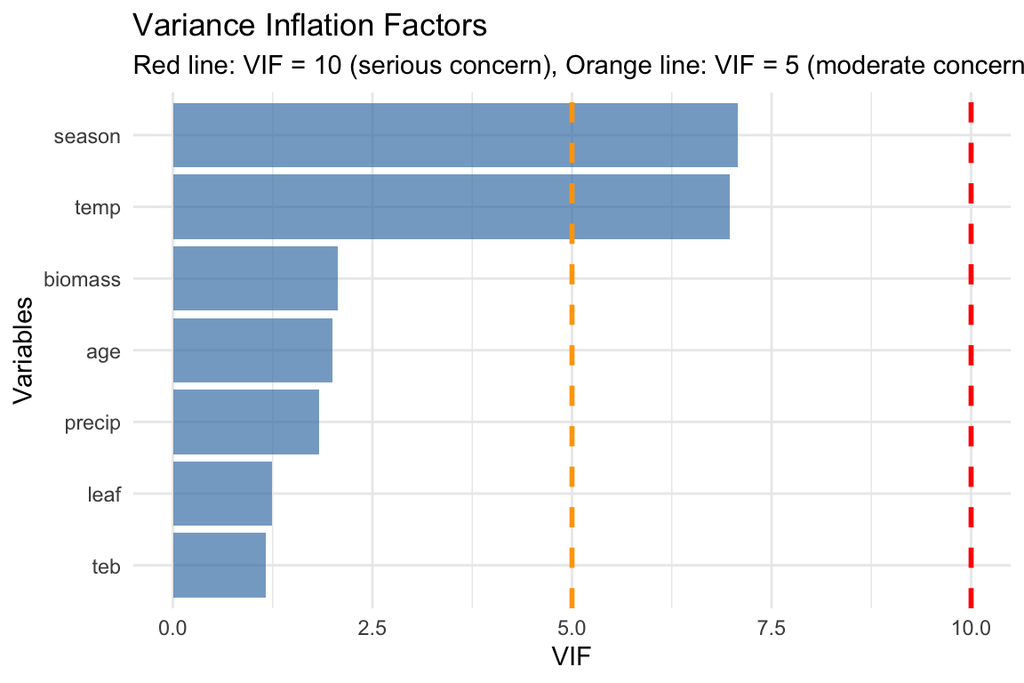

```r
# Create a data frame for better visualization
vif_df <- data.frame(
  Variable = names(vif_values),
  VIF = as.numeric(vif_values)
) %>%
  arrange(desc(VIF))

# Visualize VIF values
ggplot(vif_df, aes(x = reorder(Variable, VIF), y = VIF)) +
  geom_col(fill = "steelblue", alpha = 0.7) +
  geom_hline(yintercept = 10, color = "red", linetype = "dashed",
             linewidth = 1) +
  geom_hline(yintercept = 5, color = "orange", linetype = "dashed",
             linewidth = 1) +
  coord_flip() +
  labs(
    title = "Variance Inflation Factors",
    subtitle = "Red line: VIF = 10 (serious concern), Orange line: VIF = 5 (moderate concern)",
    x = "Variables",
    y = "VIF"
  ) +
  theme_minimal()
```

### Address Multicollinearity by Removing Growing Season

Based on the original analysis, season and Temperature are highly correlated. Let’s remove season:

```r
# Model 2: Remove season due to multicollinearity
model2 <- lm(npp ~ age + biomass + temp + precip + teb + leaf,
             data = forest_clean)

# Model summary
summary(model2)
```

```
Call:
lm(formula = npp ~ age + biomass + temp + precip + teb + leaf,
    data = forest_clean)

Residuals:
     Min       1Q   Median       3Q      Max
-1309.94  -209.40   -42.65   167.71  2898.47

Coefficients:
              Estimate Std. Error t value Pr(>|t|)
(Intercept)  7.511e+02  3.785e+01  19.845  < 2e-16 ***
age         -5.004e+00  2.829e-01 -17.690  < 2e-16 ***
biomass      3.180e-02  1.228e-03  25.905  < 2e-16 ***
temp         2.112e+01  2.173e+00   9.718  < 2e-16 ***
precip       1.120e-01  2.851e-02   3.929 9.02e-05 ***
teb         -2.255e+00  1.092e+00  -2.066    0.039 *
leafneedle  -2.634e+02  2.258e+01 -11.666  < 2e-16 ***
---
Signif. codes:  0 '***' 0.001 '**' 0.01 '*' 0.05 '.' 0.1 ' ' 1

Residual standard error: 354.3 on 1213 degrees of freedom
Multiple R-squared:  0.6359,    Adjusted R-squared:  0.6341
F-statistic: 353.1 on 6 and 1213 DF,  p-value: < 2.2e-16
```

```r
# Check VIF again
vif_values2 <- vif(model2)
print("VIF values after removing season:")
```

```
[1] "VIF values after removing season:"
```

```r
print(vif_values2)
```

```
     age  biomass     temp   precip      teb     leaf
1.932806 2.056724 1.696787 1.803266 1.166162 1.234906
```

## 3. Exploring Variable Transformations

### Check the Shape of Relationships with Partial Regression Plots

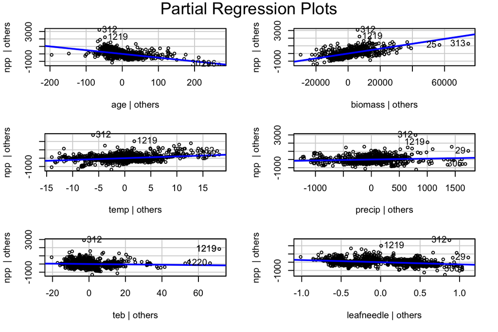

```r
# Create partial regression plots (Added Variable Plots)
# This helps us see the relationship between each predictor and response
# after accounting for other variables

par(mfrow = c(2, 3))
avPlots(model2, main = "Partial Regression Plots")
```

```r
par(mfrow = c(1, 1))
```

### Apply Log Transformation to age

The original analysis found that age showed a curvy relationship. Let’s try log transformation:

```r
# Create dataset with log-transformed age
forest_transformed <- forest_clean %>%
  mutate(log_age = log10(age))

# Model 3: With log-transformed age
model3 <- lm(npp ~ log_age + biomass + temp + precip + teb + leaf,
             data = forest_transformed)


# Model summary
summary(model3)
```

```
Call:
lm(formula = npp ~ log_age + biomass + temp + precip + teb +
    leaf, data = forest_transformed)

Residuals:
     Min       1Q   Median       3Q      Max
-1282.97  -203.31   -23.13   163.75  2810.76

Coefficients:
              Estimate Std. Error t value Pr(>|t|)
(Intercept)  2.237e+03  8.961e+01  24.962  < 2e-16 ***
log_age     -1.012e+03  5.064e+01 -19.973  < 2e-16 ***
biomass      3.313e-02  1.194e-03  27.755  < 2e-16 ***
temp         1.723e+01  2.159e+00   7.982 3.33e-15 ***
precip       7.194e-02  2.781e-02   2.587  0.00981 **
teb         -2.315e+00  1.061e+00  -2.183  0.02925 *
leafneedle  -2.852e+02  2.177e+01 -13.105  < 2e-16 ***
---
Signif. codes:  0 '***' 0.001 '**' 0.01 '*' 0.05 '.' 0.1 ' ' 1

Residual standard error: 344.7 on 1213 degrees of freedom
Multiple R-squared:  0.6553,    Adjusted R-squared:  0.6536
F-statistic: 384.4 on 6 and 1213 DF,  p-value: < 2.2e-16
```

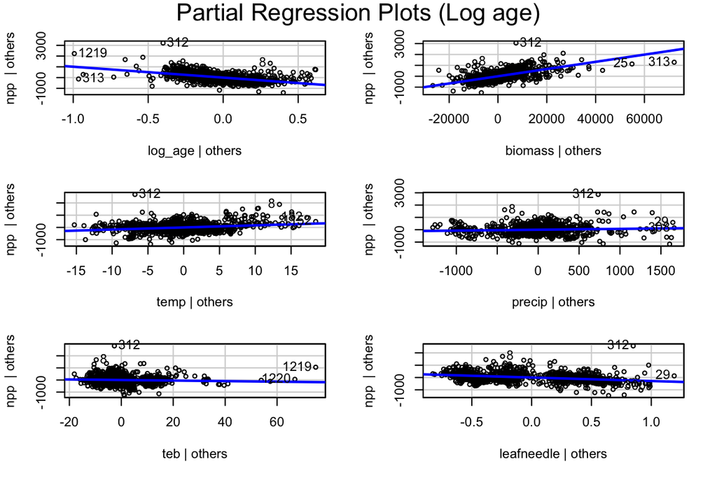

```r
# Compare partial regression plots
par(mfrow = c(2, 3))
avPlots(model3, main = "Partial Regression Plots (Log age)")
```

```r
par(mfrow = c(1, 1))
```

## 4. Model Diagnostics and Assumption Checking

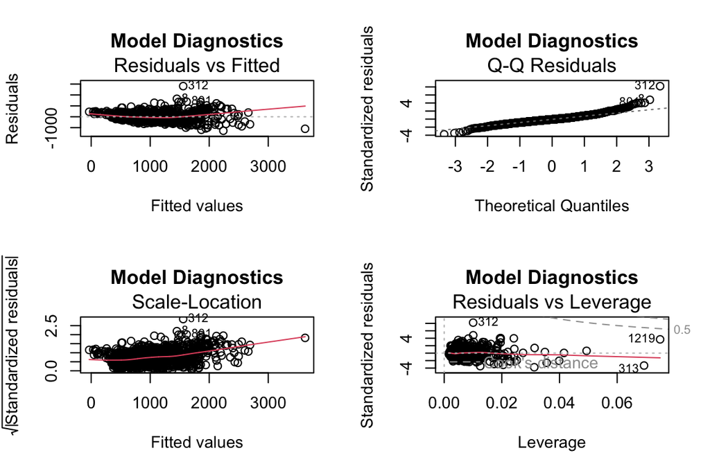

```r
# Create diagnostic plots
par(mfrow = c(2, 2))
plot(model3, main = "Model Diagnostics")
```

```r
par(mfrow = c(1, 1))
```

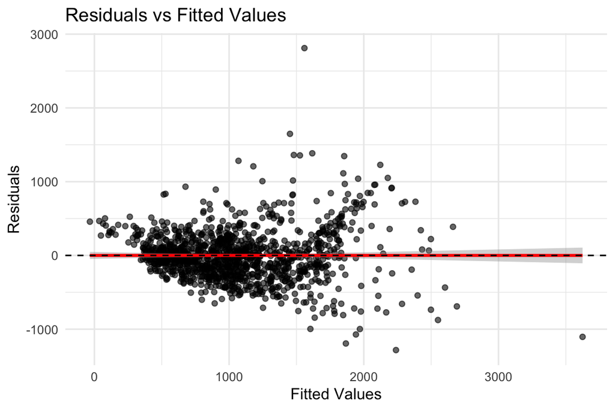

```r
# Check for normality of residuals
residuals_data <- data.frame(
  Fitted = fitted(model3),
  Residuals = residuals(model3),
  Standardized_Residuals = rstandard(model3)
)

# Residuals vs Fitted plot using ggplot
ggplot(residuals_data, aes(x = Fitted, y = Residuals)) +
  geom_point(alpha = 0.6) +
  geom_smooth(method = "lm", color = "red") +
  geom_hline(yintercept = 0, linetype = "dashed") +
  labs(
    title = "Residuals vs Fitted Values",
    x = "Fitted Values",
    y = "Residuals"
  ) +
  theme_minimal()
```

### Try Response Variable Transformation

Following the original analysis, let’s try a cube root transformation of npp:

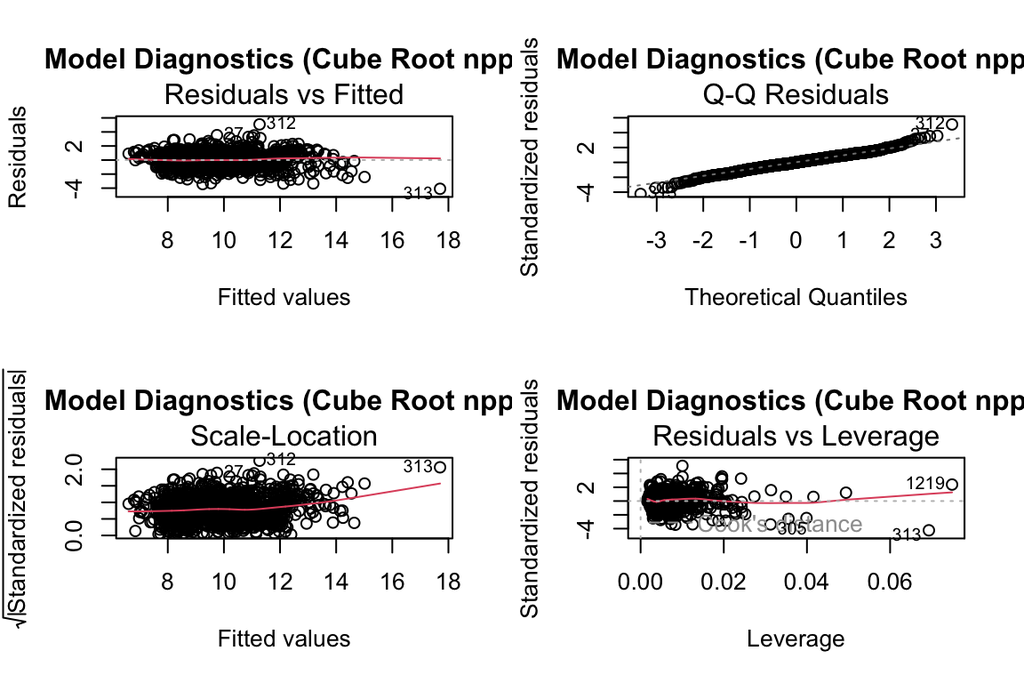

```r
# Model 4: Cube root transformation of npp
forest_transformed <- forest_transformed %>%
  mutate(npp_cuberoot = npp^(1/3))

model4 <- lm(npp_cuberoot ~ log_age + biomass + temp + precip +
             teb + leaf, data = forest_transformed)

# Check diagnostics
par(mfrow = c(2, 2))
plot(model4, main = "Model Diagnostics (Cube Root npp)")
```

```r
par(mfrow = c(1, 1))

# Model summary
tidy(model4)
```

```
# A tibble: 7 × 5
  term          estimate  std.error statistic   p.value
  <chr>            <dbl>      <dbl>     <dbl>     <dbl>
1 (Intercept) 13.9       0.260         53.5   2.06e-321
2 log_age     -3.15      0.147        -21.4   1.07e- 86
3 biomass      0.000103  0.00000346    29.8   8.32e-147
4 temp         0.0451    0.00627        7.19  1.10e- 12
5 precip       0.0000636 0.0000807      0.788 4.31e-  1
6 teb         -0.0127    0.00308       -4.13  3.79e-  5
7 leafneedle  -1.03      0.0632       -16.3   4.57e- 54
```

```r
glance(model4)
```

```
# A tibble: 1 × 12
  r.squared adj.r.squared sigma statistic   p.value    df logLik   AIC   BIC
      <dbl>         <dbl> <dbl>     <dbl>     <dbl> <dbl>  <dbl> <dbl> <dbl>
1     0.679         0.678  1.00      428. 2.43e-295     6 -1728. 3472. 3513.
# ℹ 3 more variables: deviance <dbl>, df.residual <int>, nobs <int>
```

## 5. Model Simplification and Comparison

### Remove Non-significant Variables

```r
# Model 5: Remove non-significant Precipitation
model5 <- lm(npp_cuberoot ~ log_age + biomass + temp + teb + leaf,
             data = forest_transformed)

# Compare models using AIC
model_comparison <- data.frame(
  Model = c("Model 4 (Full)", "Model 5 (No precip)"),
  AIC = c(AIC(model4), AIC(model5)),
  R_squared = c(summary(model4)$r.squared, summary(model5)$r.squared),
  Adj_R_squared = c(summary(model4)$adj.r.squared, summary(model5)$adj.r.squared)
)

print(model_comparison)
```

```
                Model      AIC R_squared Adj_R_squared
1      Model 4 (Full) 3472.092 0.6792946     0.6777082
2 Model 5 (No precip) 3470.717 0.6791304     0.6778089
```

```r
# Final model summary
cat("\n=== FINAL MODEL SUMMARY ===\n")
```

```
=== FINAL MODEL SUMMARY ===
```

```r
summary(model5)
```

```
Call:
lm(formula = npp_cuberoot ~ log_age + biomass + temp + teb +
    leaf, data = forest_transformed)

Residuals:
    Min      1Q  Median      3Q     Max
-4.1085 -0.5919  0.0019  0.6459  5.1261

Coefficients:
              Estimate Std. Error t value Pr(>|t|)
(Intercept)  1.396e+01  2.532e-01  55.120  < 2e-16 ***
log_age     -3.159e+00  1.465e-01 -21.559  < 2e-16 ***
biomass      1.040e-04  3.306e-06  31.465  < 2e-16 ***
temp         4.719e-02  5.658e-03   8.342  < 2e-16 ***
teb         -1.296e-02  3.064e-03  -4.231  2.5e-05 ***
leafneedle  -1.040e+00  6.150e-02 -16.910  < 2e-16 ***
---
Signif. codes:  0 '***' 0.001 '**' 0.01 '*' 0.05 '.' 0.1 ' ' 1

Residual standard error: 1 on 1214 degrees of freedom
Multiple R-squared:  0.6791,    Adjusted R-squared:  0.6778
F-statistic: 513.9 on 5 and 1214 DF,  p-value: < 2.2e-16
```

### Model Performance and Interpretation

```r
# Get tidy summary of final model
final_summary <- tidy(model5, conf.int = TRUE)

# Get tidy summary of final model
summary(model5, conf.int = TRUE)
```

```
Call:
lm(formula = npp_cuberoot ~ log_age + biomass + temp + teb +
    leaf, data = forest_transformed)

Residuals:
    Min      1Q  Median      3Q     Max
-4.1085 -0.5919  0.0019  0.6459  5.1261

Coefficients:
              Estimate Std. Error t value Pr(>|t|)
(Intercept)  1.396e+01  2.532e-01  55.120  < 2e-16 ***
log_age     -3.159e+00  1.465e-01 -21.559  < 2e-16 ***
biomass      1.040e-04  3.306e-06  31.465  < 2e-16 ***
temp         4.719e-02  5.658e-03   8.342  < 2e-16 ***
teb         -1.296e-02  3.064e-03  -4.231  2.5e-05 ***
leafneedle  -1.040e+00  6.150e-02 -16.910  < 2e-16 ***
---
Signif. codes:  0 '***' 0.001 '**' 0.01 '*' 0.05 '.' 0.1 ' ' 1

Residual standard error: 1 on 1214 degrees of freedom
Multiple R-squared:  0.6791,    Adjusted R-squared:  0.6778
F-statistic: 513.9 on 5 and 1214 DF,  p-value: < 2.2e-16
```

```r
# Calculate partial R-squared for each variable
# Using the sensemakr package equivalent or manual calculation
anova_table <- anova(model5)
print("ANOVA Table:")
```

```
[1] "ANOVA Table:"
```

```r
print(anova_table)
```

```
Analysis of Variance Table

Response: npp_cuberoot
            Df  Sum Sq Mean Sq  F value    Pr(>F)
log_age      1  193.32  193.32  193.239 < 2.2e-16 ***
biomass      1 1886.95 1886.95 1886.142 < 2.2e-16 ***
temp         1  179.34  179.34  179.264 < 2.2e-16 ***
teb          1   24.88   24.88   24.866 7.038e-07 ***
leaf         1  286.08  286.08  285.957 < 2.2e-16 ***
Residuals 1214 1214.52    1.00
---
Signif. codes:  0 '***' 0.001 '**' 0.01 '*' 0.05 '.' 0.1 ' ' 1
```

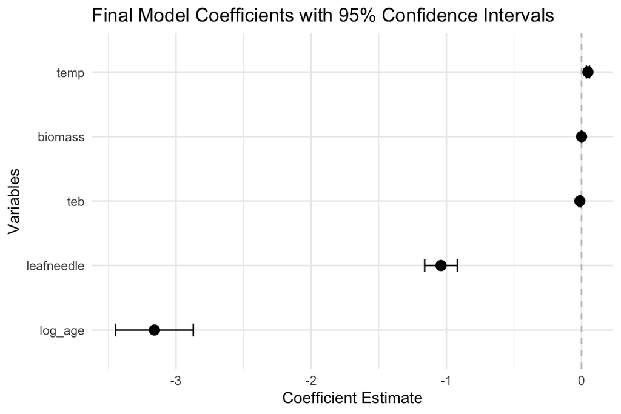

```r
# Create coefficient plot
final_summary %>%
  filter(term != "(Intercept)") %>%
  mutate(term = fct_reorder(term, estimate)) %>%
  ggplot(aes(x = estimate, y = term)) +
  geom_vline(xintercept = 0, linetype = "dashed", color = "gray") +
  geom_point(size = 3) +
  geom_errorbarh(aes(xmin = conf.low, xmax = conf.high), height = 0.2) +
  labs(
    title = "Final Model Coefficients with 95% Confidence Intervals",
    x = "Coefficient Estimate",
    y = "Variables"
  ) +
  theme_minimal()
```

## 6. Alternative Approach: Standardized Variables

Following the original analysis, let’s also try the standardized approach:

```r
# Create standardized variables
forest_standardized <- forest_clean %>%
  mutate(
    npp_sqrt_scaled = scale(sqrt(npp))[,1],
    log_age_scaled = scale(log10(age))[,1],
    biomass_scaled = scale(biomass)[,1],
    temp_scaled = scale(temp)[,1],
    precip_scaled = scale(precip)[,1],
    teb_scaled = scale(teb)[,1]
  )

# Standardized model
model_std <- lm(npp_sqrt_scaled ~ log_age_scaled + biomass_scaled +
                temp_scaled * precip_scaled + teb_scaled,
                data = forest_standardized)

# Summary
summary(model_std)
```

```
Call:
lm(formula = npp_sqrt_scaled ~ log_age_scaled + biomass_scaled +
    temp_scaled * precip_scaled + teb_scaled, data = forest_standardized)

Residuals:
     Min       1Q   Median       3Q      Max
-3.14438 -0.38836 -0.03068  0.39178  3.01216

Coefficients:
                           Estimate Std. Error t value Pr(>|t|)
(Intercept)               -0.064952   0.020075  -3.235 0.001247 **
log_age_scaled            -0.543699   0.024500 -22.192  < 2e-16 ***
biomass_scaled             0.691415   0.025313  27.315  < 2e-16 ***
temp_scaled                0.215693   0.023304   9.256  < 2e-16 ***
precip_scaled             -0.008188   0.028714  -0.285 0.775563
teb_scaled                -0.071775   0.018879  -3.802 0.000151 ***
temp_scaled:precip_scaled  0.112727   0.017068   6.605 5.94e-11 ***
---
Signif. codes:  0 '***' 0.001 '**' 0.01 '*' 0.05 '.' 0.1 ' ' 1

Residual standard error: 0.6113 on 1213 degrees of freedom
Multiple R-squared:  0.6281,    Adjusted R-squared:  0.6263
F-statistic: 341.5 on 6 and 1213 DF,  p-value: < 2.2e-16
```

## 7. Key Findings and Conclusions

```r
# Create a summary of key findings
cat("=== KEY FINDINGS ===\n\n")
```

```
=== KEY FINDINGS ===
```

```r
cat("1. MULTICOLLINEARITY:\n")
```

```
1. MULTICOLLINEARITY:
```

```r
cat("   - Growing season length and temperature were highly correlated\n")
```

```
   - Growing season length and temperature were highly correlated
```

```r
cat("   - Removed growing season to address multicollinearity\n\n")
```

```
   - Removed growing season to address multicollinearity
```

```r
cat("2. VARIABLE TRANSFORMATIONS:\n")
```

```
2. VARIABLE TRANSFORMATIONS:
```

```r
cat("   - Log transformation of age improved model fit\n")
```

```
   - Log transformation of age improved model fit
```

```r
cat("   - Cube root transformation of npp addressed assumption violations\n\n")
```

```
   - Cube root transformation of npp addressed assumption violations
```

```r
cat("3. FINAL MODEL RESULTS:\n")
```

```
3. FINAL MODEL RESULTS:
```

```r
final_r2 <- summary(model5)$r.squared
cat("   - R-squared:", round(final_r2, 3), "\n")
```

```
   - R-squared: 0.679
```

```r
cat("   - Significant predictors: age (negative), biomass (positive), temp (positive)\n")
```

```
   - Significant predictors: age (negative), biomass (positive), temp (positive)
```

```r
cat("   - teb had negative effect, Leaf type differences were significant\n\n")
```

```
   - teb had negative effect, Leaf type differences were significant
```

```r
cat("4. BIOLOGICAL INTERPRETATION:\n")
```

```
4. BIOLOGICAL INTERPRETATION:
```

```r
cat("   - Younger stands had higher npp (for given biomass)\n")
```

```
   - Younger stands had higher npp (for given biomass)
```

```r
cat("   - Higher biomass associated with higher npp\n")
```

```
   - Higher biomass associated with higher npp
```

```r
cat("   - temp positively related to npp\n")
```

```
   - temp positively related to npp
```

```r
cat("   - Coniferous forests had lower npp than broadleaf forests\n")
```

```
   - Coniferous forests had lower npp than broadleaf forests
```

## References and Additional Notes

This analysis is based on:

- **Michaletz, S.T., Cheng, D., Kerkhoff, A.J. & Enquist, B.J.** (2014). Convergence of terrestrial plant production across global climate gradients. *Nature*, 512, 39-43.

**Key Learning Points:** 1. **Multicollinearity Detection**: Use VIF values and correlation matrices 2. **Variable Transformations**: Log and power transformations can improve model fit 3. **Model Diagnostics**: Always check residual plots and assumption violations 4. **Model Comparison**: Use AIC and other criteria for model selection 5. **Interpretation**: Focus on biologically meaningful relationships

**Modern R Practices Used:** - `tidyverse` for data manipulation and visualization - `broom` for tidy model outputs - `car` for regression diagnostics - `ggplot2` for modern visualizations - Pipe operators (`%>%`) for readable code - Tidy data principles throughout

Back to top